# Aula 2 - Importação, Organização e Visualização de Dados no R

# 4. Resumo Estatístico e Gráficos de Colunas

Antes de realizar testes, precisamos de estatísticas descritivas (média e desvio padrão).

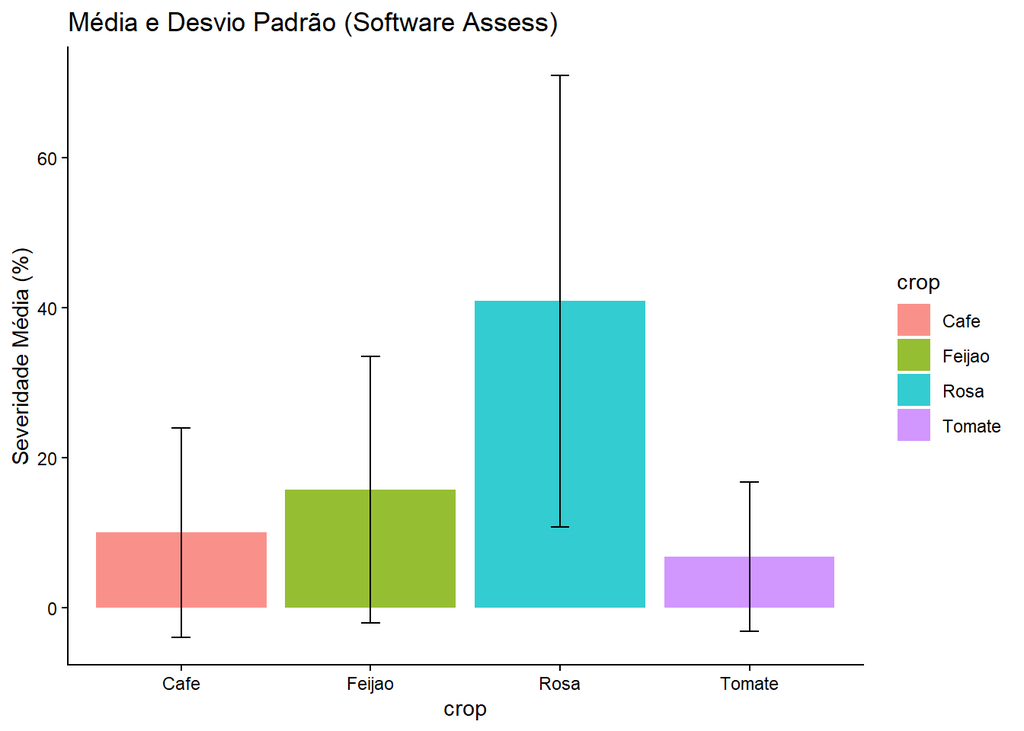

```r
# Resumo robusto filtrando o software Assess
resumo_assess <- dados_longo |>
  filter(software == "Assess") |>
  group_by(crop) |>
  summarise(
    media_severidade = mean(severidade, na.rm = TRUE),
    dp_severidade = sd(severidade, na.rm = TRUE)
  )

# Gráfico de colunas com barra de erro (Desvio Padrão)
resumo_assess |>
  ggplot(aes(x = crop, y = media_severidade, fill = crop)) +
  geom_col(alpha = 0.8) +
  geom_errorbar(aes(ymin = media_severidade - dp_severidade,
                    ymax = media_severidade + dp_severidade),
                width = 0.1) +
  theme_classic() +
  labs(y = "Severidade Média (%)", title = "Média e Desvio Padrão (Software Assess)")
```

# 5. Relação entre Variáveis (Correlação)

Para avaliar se dois softwares concordam entre si, utilizamos o gráfico de dispersão e o Coeficiente de Correlação de Pearson ($r$).

- $r = 1$: Correlação positiva perfeita.
- $r = 0$: Ausência de relação linear.
- A linha `geom_abline` (intercepto 0, inclinação 1) representa a concordância perfeita.

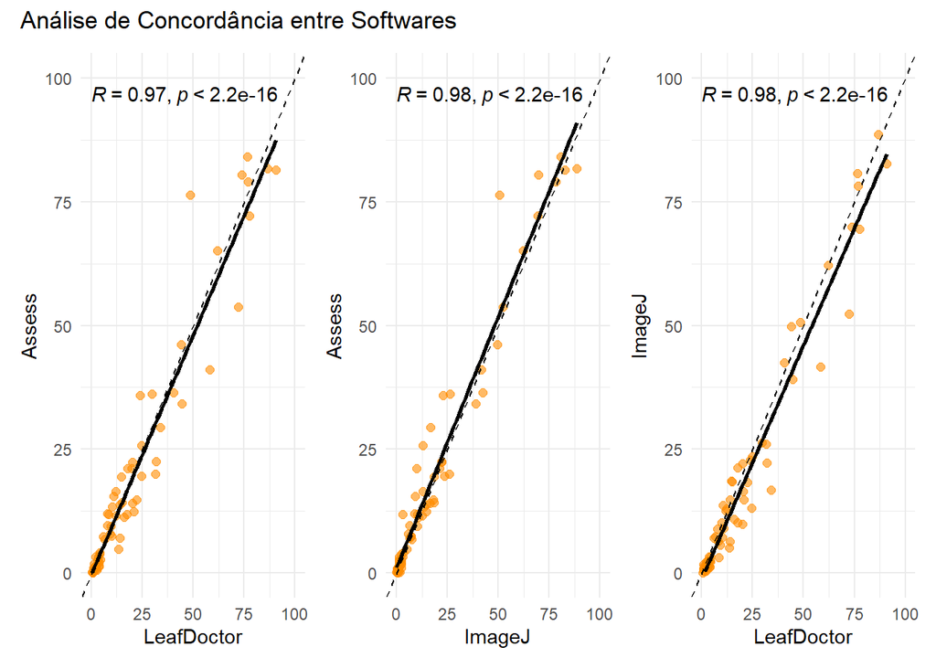

```r
library(ggpubr)
library(patchwork)

# Função para criar gráfico de correlação padronizado
criar_cor_plot <- function(data, x_var, y_var) {
  ggplot(data, aes(x = .data[[x_var]], y = .data[[y_var]])) +
    geom_point(size = 2, color = "darkorange", alpha = 0.6) +
    geom_smooth(method = "lm", se = FALSE, color = "black") +
    geom_abline(intercept = 0, slope = 1, linetype = 2) + # Linha de identidade (1:1)
    stat_cor(method = "pearson") +
    ylim(0, 100) + xlim(0, 100) +
    theme_minimal()
}

p1 <- criar_cor_plot(software, "LeafDoctor", "Assess")
p2 <- criar_cor_plot(software, "ImageJ", "Assess")
p3 <- criar_cor_plot(software, "LeafDoctor", "ImageJ")

# Combinando gráficos com patchwork
(p1 | p2 | p3) + plot_annotation(title = "Análise de Concordância entre Softwares")
```

# 6. Observações Finais sobre o Fluxo

Este código ilustra um fluxo de trabalho reprodutível: 1. **Importação**: Dados locais ou remotos. 2. **Limpeza/Tidy**: Uso de `pivot_longer` para organizar a estrutura. 3. **Transformação**: `filter` e `group_by` para segmentar a análise. 4. **Resumo**: Cálculo de métricas centrais e de dispersão. 5. **Comunicação**: Visualização clara com `ggplot2` e exportação com `ggsave()`.

```r
# Exemplo de salvamento de gráfico
# ggsave("meu_painel_correlacao.png", width = 10, height = 4, bg = "white")
```